# Illustration of the workflow for a modelling study using dynConfiR

Sebastian Hellmann

#### For dynConfiR version 1.0.0

This vignette illustrates the whole workflow for a modelling study using the `dynConfiR` package. A detailed description of the package and the implemented models can be found in Hellmann et al. (preprint). The basic workflow of a modelling study is illustrated together with the respective functions implemented in the package in the following chart:

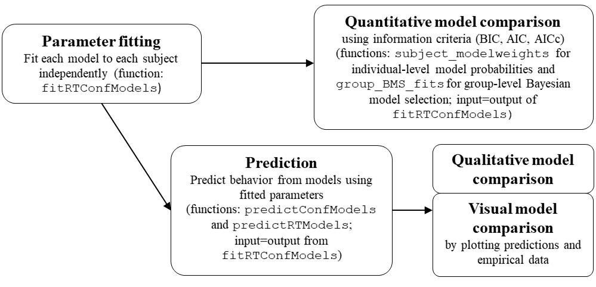

Workflow of modeling study using dynConfiR

```r
library(dynConfiR)
library(tidyverse)
```

## Step 0: Data preparation

For this illustration, we load the `ConfidenceOrientation` dataset, which is contained in the `dynConfiR` package. The dataset contains results from an orientation discrimination experiment with simultaneous confidence judgments. The data set includes results from 16 participants and 3 sessions each. The task was to identify the orientation (horizontal (“waagrecht”) or vertical (“senkrecht”)) of a grid that was briefly visible and then covered by a mask in form of a checkerboard pattern. The stimulus-onset-asynchrony (SOA) was manipulated in 5 steps. Confidence was reported using a joystick on a continuous visual analogue scale with values between -1 and 1.

```r
data("ConfidenceOrientation")
data <- ConfidenceOrientation %>%
  select(participant, SOA, stimulus, response, correct, rt, cont_rating)
head(ConfidenceOrientation)
```

```
#> # A tibble: 6 × 12
#>   participant session gender   age   SOA orientation stimulus  response  correct
#>         <dbl>   <dbl> <chr>  <dbl> <dbl>       <dbl> <chr>     <chr>       <dbl>
#> 1           1       1 w         23   8.3           0 senkrecht senkrecht       1
#> 2           1       1 w         23 133.           90 waagrecht senkrecht       0
#> 3           1       1 w         23  33.3           0 senkrecht senkrecht       1
#> 4           1       1 w         23  16.7          90 waagrecht senkrecht       0
#> 5           1       1 w         23 133.            0 senkrecht senkrecht       1
#> 6           1       1 w         23  16.7           0 senkrecht senkrecht       1
#> # ℹ 3 more variables: rt <dbl>, cont_rating <dbl>, disc_rating <dbl>
```

```r
head(data)
```

```
#> # A tibble: 6 × 7
#>   participant   SOA stimulus  response  correct    rt cont_rating
#>         <dbl> <dbl> <chr>     <chr>       <dbl> <dbl>       <dbl>
#> 1           1   8.3 senkrecht senkrecht       1  2.89      -0.969
#> 2           1 133.  waagrecht senkrecht       0  3.06       0.817
#> 3           1  33.3 senkrecht senkrecht       1  2.83      -1
#> 4           1  16.7 waagrecht senkrecht       0  2.65      -1
#> 5           1 133.  senkrecht senkrecht       1  2.92       0.270
#> 6           1  16.7 senkrecht senkrecht       1  3.17      -0.992
```

There are several steps of data preparation, which are either necessary or recommended. First, the models implemented in `dynConfiR` all require confidence to be measured on a discrete scale, so we discretize the contionuous confidence rating. We do this using equidistant breaks. The functions would be fine with any integer or factor column, so we simply use the cut function.

```r
data <- data %>%
  mutate(confidence = cut(cont_rating, breaks = seq(-1, 1, length.out=6), include.lowest = TRUE,
                          labels=1:5))
head(data)
```

```
#> # A tibble: 6 × 8
#>   participant   SOA stimulus  response  correct    rt cont_rating confidence
#>         <dbl> <dbl> <chr>     <chr>       <dbl> <dbl>       <dbl> <fct>
#> 1           1   8.3 senkrecht senkrecht       1  2.89      -0.969 1
#> 2           1 133.  waagrecht senkrecht       0  3.06       0.817 5
#> 3           1  33.3 senkrecht senkrecht       1  2.83      -1     1
#> 4           1  16.7 waagrecht senkrecht       0  2.65      -1     1
#> 5           1 133.  senkrecht senkrecht       1  2.92       0.270 4
#> 6           1  16.7 senkrecht senkrecht       1  3.17      -0.992 1
```

Second, it is recommended to exclude trials with very fast and slow response times. We do this using a sharp threshold of 300ms for fast response times and an individual upper threshold for each participant equal to the mean plus three times standard deviation. In addition, we exclude participants that showed guessing-level performance in the identification judgment, defined by the critical threshold of a binomial test. Finally, we exclude participants, which showed no variation in their confidence judgments, defined by reporting the same discrete confidence in at least 90% of the trials.

```r
### Exclusion of participants
exclusion_crit <- data %>% group_by(participant) %>%
  reframe(bad_performance = binom.test(sum(correct), n(), p=0.5, alternative="greater")$p.value,
          prob_mode_conf = max(table(confidence))/n()) %>%
  mutate(bad_performance = bad_performance > 0.05,
         no_conf_variation = prob_mode_conf>.90)
print(t(exclusion_crit))
```

```
#>                        [,1]      [,2]      [,3]      [,4]      [,5]      [,6]
#> participant       1.0000000 2.0000000 3.0000000 4.0000000 5.0000000 6.0000000
#> bad_performance   0.0000000 0.0000000 0.0000000 0.0000000 0.0000000 0.0000000
#> prob_mode_conf    0.4092593 0.4277778 0.5709877 0.5425926 0.5290123 0.3641975
#> no_conf_variation 0.0000000 0.0000000 0.0000000 0.0000000 0.0000000 0.0000000
#>                        [,7]      [,8]      [,9]     [,10]      [,11]      [,12]
#> participant       7.0000000 8.0000000 9.0000000 10.000000 11.0000000 12.0000000
#> bad_performance   0.0000000 0.0000000 0.0000000  0.000000  0.0000000  0.0000000
#> prob_mode_conf    0.5246914 0.4981481 0.3641975  0.795679  0.6259259  0.4759259
#> no_conf_variation 0.0000000 0.0000000 0.0000000  0.000000  0.0000000  0.0000000
#>                        [,13]      [,14]      [,15]      [,16]
#> participant       13.0000000 14.0000000 15.0000000 16.0000000
#> bad_performance    0.0000000  0.0000000  0.0000000  0.0000000
#> prob_mode_conf     0.6006173  0.4037037  0.4432099  0.5401235
#> no_conf_variation  0.0000000  0.0000000  0.0000000  0.0000000
```

```r
excluded_parts <- exclusion_crit %>% filter(bad_performance | no_conf_variation) %>%
  pull(participant)
data <- data %>% filter(!participant %in% excluded_parts)
### Result: No participant was excluded

### Exclusion of trials:
nrow_tot <- nrow(data)
data <- data %>% group_by(participant) %>%
  filter((rt > 0.3) & (rt <mean(rt)+3*sd(rt)))
cat("We excluded ", 1- nrow(data)/nrow_tot, " of all trials because of RT's.\n")
```

```
#> We excluded  0.01296296  of all trials because of RT's.
```